# Evaluación 1 - Introducción a Ciencia de Datos Espaciales

Estudiante: Pierina Milla

## 1. Merge de las 3 fuentes seleccionadas

Importo la librería Pandas y leo los 3 archivos con la data que han sido subidos al repositorio Github.

1. Emisiones de CO2 sin LULUCF
   - Unidad: Kilotones
   - Fuente: United Nations Framework Convention on Climate Change
   - Año: 1990
2. Precipitation
   - Unidad: Milímetros
   - Fuente: World Metereological Organization
   - Periodo: 1958-1990
3. Solar electricity
   - Unidad: millones Kilowatt-hora
   - Fuente: United Nations Statistics Division
   - Año: 2020

```python
import pandas as pd

co2Link='https://github.com/IntroSpatialDataScience/ClimateChangeData/raw/main/data/CO2_1990.csv'
precipitationLink = 'https://github.com/IntroSpatialDataScience/ClimateChangeData/raw/main/data/precipitation_mean.csv'
solarElectricityLink = 'https://github.com/IntroSpatialDataScience/ClimateChangeData/raw/main/data/solar_energy.csv'
co2=pd.read_csv(co2Link)
precipitation=pd.read_csv(precipitationLink)
solar = pd.read_csv(solarElectricityLink)
```

Realizo una copia de cada dataframe para trabajar sin modificar el archivo original

```python
co2_new=co2.copy()
precipitation_new=precipitation.copy()
solar_new=solar.copy()
```

Cambio los nombres de las columnas referentes al territorio o país de cada DF para facilitar el merge entre ellos.

```python
co2_new.rename(columns={'Country or Area':'Country'}, inplace=True)
precipitation_new.rename(columns={'Country or Territory':'Country'}, inplace=True)
solar_new.rename(columns={'Country or Area':'Country'}, inplace=True)
```

Toda la data en el mismo formato 'title':

```python
precipitation_new.Country = precipitation_new.Country.str.title()
co2_new.Country = co2_new.Country.str.title()
solar_new.Country = solar_new.Country.str.title()
```

El número de filas y columnas de cada dataframe es:

```python
co2_new.shape,precipitation_new.shape,solar_new.shape
```

```
((43, 3), (4263, 33), (205, 5))
```

```python
co2_new.columns,precipitation_new.columns,solar_new.columns
```

```
(Index(['Country', 'Year', 'Value'], dtype='object'),
 Index(['Country', 'Station Name', 'Period', 'Statistic Description', 'Unit',
        'Jan', 'Jan Footnotes', 'Feb', 'Feb Footnotes', 'Mar', 'Mar Footnotes',
        'Apr', 'Apr Footnotes', 'May', 'May Footnotes', 'Jun', 'Jun Footnotes',
        'Jul', 'Jul Footnotes', 'Aug', 'Aug Footnotes', 'Sep', 'Sep Footnotes',
        'Oct', 'Oct Footnotes', 'Nov', 'Nov Footnotes', 'Dec', 'Dec Footnotes',
        'Annual', 'Annual Footnotes', 'Annual NCDC Computed Value',
        'Annual NCDC Computed Value Footnotes'],
       dtype='object'),
 Index(['Country', 'Year', 'Unit', 'Quantity', 'Quantity Footnotes'], dtype='object'))
```

#### Fuzzy Merge

```python
#Países que se encuentran solo en CO2 dataframe y no en solarDataframe
OnlyCO2=set(co2_new.Country)-set(solar_new.Country)
OnlyCO2
```

```
{'European Union', 'Iceland', 'Monaco', 'United States Of America'}
```

```python
#Países que se encuentran solo en solar dataframe y no en CO2 dataframe
OnlySolar=set(solar_new.Country)-set(co2_new.Country)
OnlySolar
```

```
{'1',
 'Afghanistan',
 'Albania',
 'Algeria',
 'American Samoa',
 'Andorra',
 'Angola',
 'Anguilla',
 'Antigua And Barbuda',
 'Argentina',
 'Armenia',
 'Aruba',
 'Azerbaijan',
 'Bahamas',
 'Bahrain',
 'Bangladesh',
 'Barbados',
 'Belize',
 'Benin',
 'Bermuda',
 'Bhutan',
 'Bolivia (Plur. State Of)',
 'Bonaire, St Eustatius, Saba',
 'Bosnia And Herzegovina',
 'Botswana',
 'Brazil',
 'British Virgin Islands',
 'Brunei Darussalam',
 'Burkina Faso',
 'Burundi',
 'Cabo Verde',
 'Cambodia',
 'Cameroon',
 'Central African Rep.',
 'Chile',
 'China',
 'Colombia',
 'Congo',
 'Cook Islands',
 'Costa Rica',
```

[output cut: 111 more lines]

```
 'Tuvalu',
 'Uganda',
 'United Arab Emirates',
 'United Rep. Of Tanzania',
 'United States',
 'United States Virgin Is.',
 'Uruguay',
 'Uzbekistan',
 'Vanuatu',
 'Venezuela (Bolivar. Rep.)',
 'Viet Nam',
 'Wallis And Futuna Is.',
 'Yemen',
 'Zambia',
 'Zimbabwe'}
```

```python
from thefuzz import process as fz

# Tomamos un pais de OnlySolar
# Miramos en un país de OnlyCO2 y retornamos el más similar
[(f,fz.extractOne(f, OnlySolar)) for f in sorted(OnlyCO2)]
```

```
[('European Union', ('Benin', 60)),
 ('Iceland', ('Thailand', 67)),
 ('Monaco', ('Morocco', 62)),
 ('United States Of America', ('United States', 90))]
```

Selecciono los mejores matches:

```python
match_CO2_Solar = [(f,fz.extractOne(f, OnlySolar)) for f in sorted(OnlyCO2)
 if fz.extractOne(f, OnlySolar)[1]>=87]
match_CO2_Solar= {f:fz.extractOne(f, OnlySolar)[0]
                 for f in sorted(OnlyCO2)
                 if fz.extractOne(f, OnlySolar)[1] >=87}
match_CO2_Solar
```

```
{'United States Of America': 'United States'}
```

Reemplazo los nuevos nombres en el dataframe de CO2

```python
co2_new.Country.replace(to_replace=match_CO2_Solar,inplace=True)
co2_new
```

|  | Country | Year | Value |
| --- | --- | --- | --- |
| 0 | Australia | 1990 | 2.781542e+05 |
| 1 | Austria | 1990 | 6.214525e+04 |
| 2 | Belarus | 1990 | 1.083451e+05 |
| 3 | Belgium | 1990 | 1.202926e+05 |
| 4 | Bulgaria | 1990 | 7.669920e+04 |
| 5 | Canada | 1990 | 4.582183e+05 |
| 6 | Croatia | 1990 | 2.297979e+04 |
| 7 | Cyprus | 1990 | 4.653217e+03 |
| 8 | Czechia | 1990 | 1.642107e+05 |
| 9 | Denmark | 1990 | 5.487931e+04 |
| 10 | Estonia | 1990 | 3.692221e+04 |
| 11 | European Union | 1990 | 4.470262e+06 |
| 12 | Finland | 1990 | 5.691434e+04 |
| 13 | France | 1990 | 4.009646e+05 |
| 14 | Germany | 1990 | 1.051979e+06 |
| 15 | Greece | 1990 | 8.343804e+04 |
| 16 | Hungary | 1990 | 7.322554e+04 |
| 17 | Iceland | 1990 | 2.215856e+03 |
| 18 | Ireland | 1990 | 3.294442e+04 |
| 19 | Italy | 1990 | 4.395498e+05 |
| 20 | Japan | 1990 | 1.158129e+06 |
| 21 | Latvia | 1990 | 1.966140e+04 |
| 22 | Liechtenstein | 1990 | 1.989709e+02 |
| 23 | Lithuania | 1990 | 3.576773e+04 |
| 24 | Luxembourg | 1990 | 1.182335e+04 |
| 25 | Malta | 1990 | 2.394194e+03 |
| 26 | Monaco | 1990 | 9.822834e+01 |
| 27 | Netherlands | 1990 | 1.618069e+05 |
| 28 | New Zealand | 1990 | 2.550251e+04 |
| 29 | Norway | 1990 | 3.509663e+04 |
| 30 | Poland | 1990 | 3.768136e+05 |
| 31 | Portugal | 1990 | 4.532509e+04 |
| 32 | Romania | 1990 | 1.734639e+05 |
| 33 | Russian Federation | 1990 | 2.534865e+06 |
| 34 | Slovakia | 1990 | 6.147019e+04 |
| 35 | Slovenia | 1990 | 1.509485e+04 |
| 36 | Spain | 1990 | 2.313284e+05 |
| 37 | Sweden | 1990 | 5.758009e+04 |
| 38 | Switzerland | 1990 | 4.415988e+04 |
| 39 | Türkiye | 1990 | 1.516645e+05 |
| 40 | Ukraine | 1990 | 7.058300e+05 |
| 41 | United Kingdom | 1990 | 6.026521e+05 |
| 42 | United States | 1990 | 5.122496e+06 |

Merge entre dataframe de CO2 y SolarEnergy manteniendo lo que es común en ambas columnas

```python
co2_solar = co2_new.merge(solar_new,how='inner',left_on='Country',right_on='Country')
co2_solar
```

|  | Country | Year_x | Value | Year_y | Unit | Quantity | Quantity Footnotes |
| --- | --- | --- | --- | --- | --- | --- | --- |
| 0 | Australia | 1990 | 2.781542e+05 | 2020 | Kilowatt-hours, million | 21033.194 | NaN |
| 1 | Austria | 1990 | 6.214525e+04 | 2020 | Kilowatt-hours, million | 2042.934 | NaN |
| 2 | Belarus | 1990 | 1.083451e+05 | 2020 | Kilowatt-hours, million | 176.000 | NaN |
| 3 | Belgium | 1990 | 1.202926e+05 | 2020 | Kilowatt-hours, million | 5105.400 | NaN |
| 4 | Bulgaria | 1990 | 7.669920e+04 | 2020 | Kilowatt-hours, million | 1480.856 | NaN |
| 5 | Canada | 1990 | 4.582183e+05 | 2020 | Kilowatt-hours, million | 4846.000 | NaN |
| 6 | Croatia | 1990 | 2.297979e+04 | 2020 | Kilowatt-hours, million | 95.500 | NaN |
| 7 | Cyprus | 1990 | 4.653217e+03 | 2020 | Kilowatt-hours, million | 295.608 | NaN |
| 8 | Czechia | 1990 | 1.642107e+05 | 2020 | Kilowatt-hours, million | 2287.014 | NaN |
| 9 | Denmark | 1990 | 5.487931e+04 | 2020 | Kilowatt-hours, million | 1180.532 | NaN |
| 10 | Estonia | 1990 | 3.692221e+04 | 2020 | Kilowatt-hours, million | 122.540 | NaN |
| 11 | Finland | 1990 | 5.691434e+04 | 2020 | Kilowatt-hours, million | 218.471 | NaN |
| 12 | France | 1990 | 4.009646e+05 | 2020 | Kilowatt-hours, million | 13398.392 | NaN |
| 13 | Germany | 1990 | 1.051979e+06 | 2020 | Kilowatt-hours, million | 48641.000 | NaN |
| 14 | Greece | 1990 | 8.343804e+04 | 2020 | Kilowatt-hours, million | 4446.854 | NaN |
| 15 | Hungary | 1990 | 7.322554e+04 | 2020 | Kilowatt-hours, million | 2459.000 | NaN |
| 16 | Ireland | 1990 | 3.294442e+04 | 2020 | Kilowatt-hours, million | 63.780 | NaN |
| 17 | Italy | 1990 | 4.395498e+05 | 2020 | Kilowatt-hours, million | 24941.504 | NaN |
| 18 | Japan | 1990 | 1.158129e+06 | 2020 | Kilowatt-hours, million | 79086.858 | NaN |
| 19 | Latvia | 1990 | 1.966140e+04 | 2020 | Kilowatt-hours, million | 4.847 | NaN |
| 20 | Liechtenstein | 1990 | 1.989709e+02 | 2020 | Kilowatt-hours, million | 29.700 | NaN |
| 21 | Lithuania | 1990 | 3.576773e+04 | 2020 | Kilowatt-hours, million | 128.800 | NaN |
| 22 | Luxembourg | 1990 | 1.182335e+04 | 2020 | Kilowatt-hours, million | 161.261 | NaN |
| 23 | Malta | 1990 | 2.394194e+03 | 2020 | Kilowatt-hours, million | 236.837 | NaN |
| 24 | Netherlands | 1990 | 1.618069e+05 | 2020 | Kilowatt-hours, million | 8765.172 | NaN |
| 25 | New Zealand | 1990 | 2.550251e+04 | 2020 | Kilowatt-hours, million | 160.216 | NaN |
| 26 | Norway | 1990 | 3.509663e+04 | 2020 | Kilowatt-hours, million | 26.521 | NaN |
| 27 | Poland | 1990 | 3.768136e+05 | 2020 | Kilowatt-hours, million | 1957.916 | NaN |
| 28 | Portugal | 1990 | 4.532509e+04 | 2020 | Kilowatt-hours, million | 1715.590 | NaN |
| 29 | Romania | 1990 | 1.734639e+05 | 2020 | Kilowatt-hours, million | 1733.375 | NaN |
| 30 | Russian Federation | 1990 | 2.534865e+06 | 2020 | Kilowatt-hours, million | 2022.400 | NaN |
| 31 | Slovakia | 1990 | 6.147019e+04 | 2020 | Kilowatt-hours, million | 663.000 | NaN |
| 32 | Slovenia | 1990 | 1.509485e+04 | 2020 | Kilowatt-hours, million | 368.196 | NaN |
| 33 | Spain | 1990 | 2.313284e+05 | 2020 | Kilowatt-hours, million | 20667.000 | NaN |
| 34 | Sweden | 1990 | 5.758009e+04 | 2020 | Kilowatt-hours, million | 1051.000 | NaN |
| 35 | Switzerland | 1990 | 4.415988e+04 | 2020 | Kilowatt-hours, million | 2598.659 | NaN |
| 36 | Türkiye | 1990 | 1.516645e+05 | 2020 | Kilowatt-hours, million | 10950.180 | NaN |
| 37 | Ukraine | 1990 | 7.058300e+05 | 2020 | Kilowatt-hours, million | 5969.400 | NaN |
| 38 | United Kingdom | 1990 | 6.026521e+05 | 2020 | Kilowatt-hours, million | 13157.994 | NaN |
| 39 | United States | 1990 | 5.122496e+06 | 2020 | Kilowatt-hours, million | 119328.543 | NaN |

```python
OnlyCO2_Solar=set(co2_solar.Country)-set(precipitation_new.Country)
OnlyCO2_Solar
```

```
{'Czechia',
 'Liechtenstein',
 'Russian Federation',
 'Türkiye',
 'United Kingdom',
 'United States'}
```

```python
OnlyPrep=set(precipitation_new.Country)-set(co2_solar.Country)
OnlyPrep
```

```
{'1',
 '2',
 '3',
 'Afghanistan, Islamic State Of',
 'Albania',
 'Algeria',
 'Argentina',
 'Argentina (Antarctic Stations)',
 'Armenia',
 'Australia (Antarctic Stations)',
 'Azerbaijan',
 'Bahamas',
 'Bahrain',
 'Belize',
 'Benin',
 'Bosnia And Herzegovina',
 'Brazil',
 'Brunei Darussalam',
 'Cameroon',
 'Cape Verde',
 'Chad',
 'Chile',
 'Chile (Antarctic Stations)',
 'China',
 'Colombia',
 'Colombia (San Andres And Providencia Islands)',
 'Costa Rica',
 'Cuba',
 'Czech Republic',
 'Djibouti',
 'Dominica',
 'Dominican Republic',
 'Ecuador',
 'Egypt',
 'El Salvador',
 'Eritrea',
 'Fiji',
 'Footnoteseqid',
 'France (Caribbean Islands, Guadeloupe, Martinique)',
 'France (French Department Of Guyana)',
```

[output cut: 66 more lines]

```
 'Trinidad And Tobago',
 'Tunisia',
 'Turkey',
 'Turkmenistan',
 'United Arab Emirates',
 'United Kingdom Of Great Britain & Northern Ireland',
 'United States Of America',
 'United States Of America (Antarctic Stations)',
 'United States Of America (Pacific Islands)',
 'Uruguay',
 'Uzbekistan',
 'Venezuela',
 'Yugoslavia',
 'Zambia',
 'Zimbabwe'}
```

```python
[(f,fz.extractOne(f, OnlyCO2_Solar)) for f in sorted(OnlyPrep)]
```

```
[('1', ('United Kingdom', 0)),
 ('2', ('United Kingdom', 0)),
 ('3', ('United Kingdom', 0)),
 ('Afghanistan, Islamic State Of', ('United States', 52)),
 ('Albania', ('Liechtenstein', 40)),
 ('Algeria', ('Czechia', 43)),
 ('Argentina', ('Russian Federation', 51)),
 ('Argentina (Antarctic Stations)', ('United States', 52)),
 ('Armenia', ('Czechia', 43)),
 ('Australia (Antarctic Stations)', ('United States', 52)),
 ('Azerbaijan', ('Russian Federation', 53)),
 ('Bahamas', ('United States', 33)),
 ('Bahrain', ('Russian Federation', 55)),
 ('Belize', ('Liechtenstein', 60)),
 ('Benin', ('Liechtenstein', 68)),
 ('Bosnia And Herzegovina', ('Russian Federation', 45)),
 ('Brazil', ('Russian Federation', 45)),
 ('Brunei Darussalam', ('Russian Federation', 43)),
 ('Cameroon', ('Russian Federation', 48)),
 ('Cape Verde', ('Russian Federation', 45)),
 ('Chad', ('Czechia', 68)),
 ('Chile', ('Liechtenstein', 54)),
 ('Chile (Antarctic Stations)', ('Czechia', 54)),
 ('China', ('Czechia', 67)),
 ('Colombia', ('Czechia', 40)),
 ('Colombia (San Andres And Providencia Islands)', ('Czechia', 51)),
 ('Costa Rica', ('Russian Federation', 43)),
 ('Cuba', ('Czechia', 45)),
 ('Czech Republic', ('Czechia', 75)),
 ('Djibouti', ('United Kingdom', 43)),
 ('Dominica', ('United Kingdom', 53)),
 ('Dominican Republic', ('Russian Federation', 37)),
 ('Ecuador', ('Czechia', 43)),
 ('Egypt', ('Liechtenstein', 36)),
 ('El Salvador', ('United States', 33)),
 ('Eritrea', ('United Kingdom', 47)),
 ('Fiji', ('Russian Federation', 34)),
 ('Footnoteseqid', ('United States', 44)),
 ('France (Caribbean Islands, Guadeloupe, Martinique)', ('Czechia', 51)),
 ('France (French Department Of Guyana)', ('Russian Federation', 47)),
```

[output cut: 67 more lines]

```
 ('Tunisia', ('Russian Federation', 55)),
 ('Turkey', ('Türkiye', 62)),
 ('Turkmenistan', ('Türkiye', 55)),
 ('United Arab Emirates', ('United States', 86)),
 ('United Kingdom Of Great Britain & Northern Ireland',
  ('United Kingdom', 90)),
 ('United States Of America', ('United States', 90)),
 ('United States Of America (Antarctic Stations)', ('United States', 90)),
 ('United States Of America (Pacific Islands)', ('United States', 90)),
 ('Uruguay', ('Russian Federation', 42)),
 ('Uzbekistan', ('Czechia', 47)),
 ('Venezuela', ('Russian Federation', 40)),
 ('Yugoslavia', ('Russian Federation', 45)),
 ('Zambia', ('Czechia', 46)),
 ('Zimbabwe', ('Czechia', 40))]
```

```python
[(f,fz.extractOne(f, OnlyPrep)) for f in sorted(OnlyCO2_Solar)]
#Notamos que al extraer los matchs de ambas formas se pierden datos si se toman valores >=87 o >=75 o >=62
#En algunos casos se toma datos incorrectos y en otros se obvia datos, por tanto los datos faltantes se modificarán manualmente
```

```
[('Czechia', ('Czech Republic', 75)),
 ('Liechtenstein', ('Benin', 68)),
 ('Russian Federation', ('Russian Federation (Asia)', 95)),
 ('Türkiye', ('Turkey', 62)),
 ('United Kingdom',
  ('United Kingdom Of Great Britain & Northern Ireland', 90)),
 ('United States', ('United States Of America (Pacific Islands)', 90))]
```

```python
match_CO2_Solar_Prep = [(f,fz.extractOne(f, OnlyCO2_Solar)) for f in sorted(OnlyPrep)
 if fz.extractOne(f, OnlyCO2_Solar)[1]>=87]
match_CO2_Solar_Prep
```

```
[('Russian Federation (Asia)', ('Russian Federation', 95)),
 ('Russian Federation (Europe)', ('Russian Federation', 95)),
 ('United Kingdom Of Great Britain & Northern Ireland',
  ('United Kingdom', 90)),
 ('United States Of America', ('United States', 90)),
 ('United States Of America (Antarctic Stations)', ('United States', 90)),
 ('United States Of America (Pacific Islands)', ('United States', 90))]
```

```python
match_CO2_Solar_Prep= {f:fz.extractOne(f, OnlyCO2_Solar)[0]
                 for f in sorted(OnlyPrep)
                 if fz.extractOne(f, OnlyCO2_Solar)[1] >=87}
match_CO2_Solar_Prep
```

```
{'Russian Federation (Asia)': 'Russian Federation',
 'Russian Federation (Europe)': 'Russian Federation',
 'United Kingdom Of Great Britain & Northern Ireland': 'United Kingdom',
 'United States Of America': 'United States',
 'United States Of America (Antarctic Stations)': 'United States',
 'United States Of America (Pacific Islands)': 'United States'}
```

```python
precipitation_new.Country.replace(to_replace=match_CO2_Solar_Prep,inplace=True)
```

```python
precipitation_new.Country=precipitation_new.Country.str.replace('Czech Republic', 'Czechia')
precipitation_new.loc[precipitation_new['Country']=='Czechia']
```

|  | Country | Station Name | Period | Statistic Description | Unit | Jan | Jan Footnotes | Feb | Feb Footnotes | Mar | ... | Oct | Oct Footnotes | Nov | Nov Footnotes | Dec | Dec Footnotes | Annual | Annual Footnotes | Annual NCDC Computed Value | Annual NCDC Computed Value Footnotes |
| --- | --- | --- | --- | --- | --- | --- | --- | --- | --- | --- | --- | --- | --- | --- | --- | --- | --- | --- | --- | --- | --- |
| 888 | Czechia | Cheb | 1961-1990 | Mean Monthly Value | mm | 36.1 | NaN | 29.5 | NaN | 36.3 | ... | 37.5 | NaN | 41.1 | NaN | 43.9 | NaN | 559.8 | NaN | 559.7 | NaN |
| 889 | Czechia | Praha 6, Ruzyne | 1961-1990 | Mean Monthly Value | mm | 23.6 | NaN | 22.6 | NaN | 28.1 | ... | 30.5 | NaN | 31.9 | NaN | 25.3 | NaN | 526.2 | NaN | 526.3 | NaN |
| 890 | Czechia | Brno 4, Turany | 1961-1990 | Mean Monthly Value | mm | 24.5 | NaN | 23.7 | NaN | 24.2 | ... | 30.5 | NaN | 37.5 | NaN | 27.1 | NaN | 490.1 | NaN | 490.0 | NaN |
| 891 | Czechia | Mosnov, Ostrava | 1961-1990 | Mean Monthly Value | mm | 26.7 | NaN | 30.2 | NaN | 34.0 | ... | 42.3 | NaN | 44.6 | NaN | 34.3 | NaN | 701.8 | NaN | 701.8 | NaN |

4 rows × 33 columns

```python
precipitation_new.Country=precipitation_new.Country.str.replace('Turkey', 'Türkiye')
precipitation_new.loc[precipitation_new['Country']=='Türkiye']
```

|  | Country | Station Name | Period | Statistic Description | Unit | Jan | Jan Footnotes | Feb | Feb Footnotes | Mar | ... | Oct | Oct Footnotes | Nov | Nov Footnotes | Dec | Dec Footnotes | Annual | Annual Footnotes | Annual NCDC Computed Value | Annual NCDC Computed Value Footnotes |
| --- | --- | --- | --- | --- | --- | --- | --- | --- | --- | --- | --- | --- | --- | --- | --- | --- | --- | --- | --- | --- | --- |
| 3088 | Türkiye | ZONGULDAK | 1961-1990 | Mean Monthly Value | mm | 136.9 | NaN | 91.6 | NaN | 89.8 | ... | 139.1 | NaN | 142.3 | NaN | 159.3 | NaN | -9999.9 | 1.0 | 1194.1 | NaN |
| 3089 | Türkiye | SAMSUN | 1961-1990 | Mean Monthly Value | mm | 61.4 | NaN | 50.0 | NaN | 55.8 | ... | 84.7 | NaN | 89.3 | NaN | 82.2 | NaN | -9999.9 | 1.0 | 691.5 | NaN |
| 3090 | Türkiye | GIRESUN | 1961-1990 | Mean Monthly Value | mm | 121.6 | NaN | 89.2 | NaN | 88.9 | ... | 159.6 | NaN | 142.7 | NaN | 131.3 | NaN | -9999.9 | 1.0 | 1236.1 | NaN |
| 3091 | Türkiye | RIZE | 1961-1990 | Mean Monthly Value | mm | 216.5 | NaN | 172.7 | NaN | 147.1 | ... | 272.2 | NaN | 249.5 | NaN | 242.5 | NaN | -9999.9 | 1.0 | 2171.0 | NaN |
| 3092 | Türkiye | EDIRNE | 1961-1990 | Mean Monthly Value | mm | 61.4 | NaN | 53.3 | NaN | 55.0 | ... | 44.8 | NaN | 64.0 | NaN | 70.6 | NaN | -9999.9 | 1.0 | 577.6 | NaN |
| 3093 | Türkiye | GOZTEPE | 1961-1990 | Mean Monthly Value | mm | 98.7 | NaN | 66.9 | NaN | 62.1 | ... | 70.7 | NaN | 88.9 | NaN | 121.7 | NaN | -9999.9 | 1.0 | 696.7 | NaN |
| 3094 | Türkiye | KASTAMONU | 1961-1990 | Mean Monthly Value | mm | 33.2 | NaN | 27.6 | NaN | 32.9 | ... | 39.3 | NaN | 29.3 | NaN | 37.6 | NaN | -9999.9 | 1.0 | 483.6 | NaN |
| 3095 | Türkiye | CORUM | 1961-1990 | Mean Monthly Value | mm | 41.9 | NaN | 31.3 | NaN | 36.0 | ... | 30.4 | NaN | 36.5 | NaN | 50.7 | NaN | -9999.9 | 1.0 | 449.2 | NaN |
| 3096 | Türkiye | SIVAS | 1961-1990 | Mean Monthly Value | mm | 41.4 | NaN | 36.6 | NaN | 46.1 | ... | 32.1 | NaN | 38.9 | NaN | 47.2 | NaN | -9999.9 | 1.0 | 427.4 | NaN |
| 3097 | Türkiye | ERZINCAN | 1961-1990 | Mean Monthly Value | mm | 29.4 | NaN | 29.2 | NaN | 39.1 | ... | 41.9 | NaN | 39.2 | NaN | 31.3 | NaN | -9999.9 | 1.0 | 381.2 | NaN |
| 3098 | Türkiye | ERZURUM | 1961-1990 | Mean Monthly Value | mm | 21.3 | NaN | 25.3 | NaN | 29.2 | ... | 45.8 | NaN | 36.9 | NaN | 21.3 | NaN | -9999.9 | 1.0 | 414.1 | NaN |
| 3099 | Türkiye | KARS | 1961-1990 | Mean Monthly Value | mm | 18.8 | NaN | 22.4 | NaN | 26.0 | ... | 38.5 | NaN | 25.7 | NaN | 20.8 | NaN | -9999.9 | 1.0 | 462.9 | NaN |
| 3100 | Türkiye | CANAKKALE | 1961-1990 | Mean Monthly Value | mm | 97.4 | NaN | 66.2 | NaN | 61.1 | ... | 47.8 | NaN | 88.8 | NaN | 117.5 | NaN | -9999.9 | 1.0 | 634.1 | NaN |
| 3101 | Türkiye | BURSA | 1961-1990 | Mean Monthly Value | mm | 89.6 | NaN | 85.8 | NaN | 64.0 | ... | 58.0 | NaN | 80.6 | NaN | 118.4 | NaN | -9999.9 | 1.0 | 706.1 | NaN |
| 3102 | Türkiye | ESKISEHIR | 1961-1990 | Mean Monthly Value | mm | 45.2 | NaN | 33.9 | NaN | 40.5 | ... | 28.8 | NaN | 31.0 | NaN | 50.8 | NaN | -9999.9 | 1.0 | 387.8 | NaN |
| 3103 | Türkiye | ANKARA | 1961-1990 | Mean Monthly Value | mm | 47.0 | NaN | 36.3 | NaN | 36.3 | ... | 26.8 | NaN | 33.4 | NaN | 49.0 | NaN | -9999.9 | 1.0 | 414.6 | NaN |
| 3104 | Türkiye | BALIKESIR | 1961-1990 | Mean Monthly Value | mm | 87.8 | NaN | 63.6 | NaN | 55.6 | ... | 38.0 | NaN | 78.8 | NaN | 107.8 | NaN | -9999.9 | 1.0 | 587.2 | NaN |
| 3105 | Türkiye | VAN | 1961-1990 | Mean Monthly Value | mm | 34.8 | NaN | 33.9 | NaN | 42.3 | ... | 48.3 | NaN | 42.3 | NaN | 33.5 | NaN | -9999.9 | 1.0 | 385.1 | NaN |
| 3106 | Türkiye | USAK | 1961-1990 | Mean Monthly Value | mm | 75.2 | NaN | 65.5 | NaN | 57.3 | ... | 36.1 | NaN | 58.5 | NaN | 86.2 | NaN | -9999.9 | 1.0 | 541.1 | NaN |
| 3107 | Türkiye | AFYON | 1961-1990 | Mean Monthly Value | mm | 37.3 | NaN | 34.9 | NaN | 39.8 | ... | 37.2 | NaN | 30.8 | NaN | 46.2 | NaN | -9999.9 | 1.0 | 398.6 | NaN |
| 3108 | Türkiye | KAYSERI | 1961-1990 | Mean Monthly Value | mm | 32.7 | NaN | 31.2 | NaN | 40.2 | ... | 28.2 | NaN | 36.0 | NaN | 39.3 | NaN | -9999.9 | 1.0 | 386.7 | NaN |
| 3109 | Türkiye | MALATYA | 1961-1990 | Mean Monthly Value | mm | 41.9 | NaN | 35.6 | NaN | 59.5 | ... | 40.4 | NaN | 47.0 | NaN | 42.3 | NaN | -9999.9 | 1.0 | 410.9 | NaN |
| 3110 | Türkiye | SIIRT | 1961-1990 | Mean Monthly Value | mm | 89.5 | NaN | 96.7 | NaN | 102.0 | ... | 52.7 | NaN | 81.5 | NaN | 96.9 | NaN | -9999.9 | 1.0 | 710.4 | NaN |
| 3111 | Türkiye | IZMIR | 1961-1990 | Mean Monthly Value | mm | 132.3 | NaN | 99.1 | NaN | 76.4 | ... | 40.3 | NaN | 87.1 | NaN | 153.0 | NaN | -9999.9 | 1.0 | 692.0 | NaN |
| 3112 | Türkiye | ISPARTA | 1961-1990 | Mean Monthly Value | mm | 78.7 | NaN | 74.3 | NaN | 54.6 | ... | 36.4 | NaN | 46.3 | NaN | 90.1 | NaN | -9999.9 | 1.0 | 546.2 | NaN |
| 3113 | Türkiye | KONYA | 1961-1990 | Mean Monthly Value | mm | 38.8 | NaN | 32.0 | NaN | 28.8 | ... | 31.7 | NaN | 32.5 | NaN | 44.1 | NaN | -9999.9 | 1.0 | 338.2 | NaN |
| 3114 | Türkiye | NIGDE | 1961-1990 | Mean Monthly Value | mm | 30.5 | NaN | 31.3 | NaN | 33.1 | ... | 23.7 | NaN | 30.0 | NaN | 40.1 | NaN | -9999.9 | 1.0 | 323.6 | NaN |
| 3115 | Türkiye | KAHRAMANMARAS | 1961-1990 | Mean Monthly Value | mm | 125.1 | NaN | 110.9 | NaN | 96.6 | ... | 48.7 | NaN | 77.0 | NaN | 132.0 | NaN | -9999.9 | 1.0 | 718.6 | NaN |
| 3116 | Türkiye | URFA | 1961-1990 | Mean Monthly Value | mm | 84.6 | NaN | 73.5 | NaN | 71.1 | ... | 32.5 | NaN | 42.6 | NaN | 87.0 | NaN | -9999.9 | 1.0 | 482.1 | NaN |
| 3117 | Türkiye | DIYARBAKIR | 1961-1990 | Mean Monthly Value | mm | 70.3 | NaN | 69.7 | NaN | 70.9 | ... | 34.0 | NaN | 52.2 | NaN | 75.9 | NaN | -9999.9 | 1.0 | 498.4 | NaN |
| 3118 | Türkiye | HAKKARI | 1961-1990 | Mean Monthly Value | mm | 89.3 | NaN | 105.2 | NaN | 131.1 | ... | 70.4 | NaN | 96.7 | NaN | 93.4 | NaN | -9999.9 | 1.0 | 818.4 | NaN |
| 3119 | Türkiye | MUGLA | 1961-1990 | Mean Monthly Value | mm | 243.9 | NaN | 191.9 | NaN | 121.3 | ... | 71.9 | NaN | 135.3 | NaN | 281.0 | NaN | -9999.9 | 1.0 | 1222.1 | NaN |
| 3120 | Türkiye | ANTALYA | 1961-1990 | Mean Monthly Value | mm | 237.9 | NaN | 191.0 | NaN | 101.5 | ... | 70.4 | NaN | 149.7 | NaN | 222.7 | NaN | -9999.9 | 1.0 | 1077.5 | NaN |
| 3121 | Türkiye | MERSIN | 1961-1990 | Mean Monthly Value | mm | 120.5 | NaN | 110.4 | NaN | 57.9 | ... | 40.2 | NaN | 75.7 | NaN | 135.6 | NaN | -9999.9 | 1.0 | 633.8 | NaN |
| 3122 | Türkiye | ADANA | 1961-1990 | Mean Monthly Value | mm | 117.7 | NaN | 91.8 | NaN | 68.1 | ... | 46.6 | NaN | 74.6 | NaN | 138.3 | NaN | -9999.9 | 1.0 | 698.1 | NaN |

35 rows × 33 columns

Ahora, sí se procede a realizar el merge entre el datafram anterior y el de precipitacion:

```python
co2_solar_prep = co2_solar.merge(precipitation_new,how='inner',left_on='Country',right_on='Country')
co2_solar_prep
```

|  | Country | Year_x | Value | Year_y | Unit_x | Quantity | Quantity Footnotes | Station Name | Period | Statistic Description | ... | Oct | Oct Footnotes | Nov | Nov Footnotes | Dec | Dec Footnotes | Annual | Annual Footnotes | Annual NCDC Computed Value | Annual NCDC Computed Value Footnotes |
| --- | --- | --- | --- | --- | --- | --- | --- | --- | --- | --- | --- | --- | --- | --- | --- | --- | --- | --- | --- | --- | --- |
| 0 | Australia | 1990 | 2.781542e+05 | 2020 | Kilowatt-hours, million | 21033.194 | NaN | ALBANY (ALBANY TOWN) | 1961-1965 | Mean Monthly Value | ... | 96.0 | NaN | 37.9 | NaN | 23.0 | NaN | -9999.9 | 1.0 | 1012.3 | NaN |
| 1 | Australia | 1990 | 2.781542e+05 | 2020 | Kilowatt-hours, million | 21033.194 | NaN | ESPERANCE (ESPERANCE POST OFFICE) | 1961-1969 | Mean Monthly Value | ... | 51.3 | NaN | 19.3 | NaN | 17.9 | NaN | -9999.9 | 1.0 | 698.8 | NaN |
| 2 | Australia | 1990 | 2.781542e+05 | 2020 | Kilowatt-hours, million | 21033.194 | NaN | TENNANT CRK POST OFFICE WAS 014050 | 1961-1970 | Mean Monthly Value | ... | 14.3 | NaN | 11.8 | NaN | 40.6 | NaN | -9999.9 | 1.0 | 321.3 | NaN |
| 3 | Australia | 1990 | 2.781542e+05 | 2020 | Kilowatt-hours, million | 21033.194 | NaN | LONGREACH POST OFFICE | 1961-1973 | Mean Monthly Value | ... | 19.6 | NaN | 22.3 | NaN | 84.1 | NaN | -9999.9 | 1.0 | 433.7 | NaN |
| 4 | Australia | 1990 | 2.781542e+05 | 2020 | Kilowatt-hours, million | 21033.194 | NaN | ESSENDON AIRPORT AMO | 1961-1972 | Mean Monthly Value | ... | 51.5 | NaN | 42.7 | NaN | 57.5 | NaN | -9999.9 | 1.0 | 594.9 | NaN |
| ... | ... | ... | ... | ... | ... | ... | ... | ... | ... | ... | ... | ... | ... | ... | ... | ... | ... | ... | ... | ... | ... |
| 2570 | United States | 1990 | 5.122496e+06 | 2020 | Kilowatt-hours, million | 119328.543 | NaN | POHNPEI, PI | 1961-1990 | Mean Monthly Value | ... | 424.4 | NaN | 399.8 | NaN | 386.6 | NaN | 4769.1 | NaN | 4769.1 | NaN |
| 2571 | United States | 1990 | 5.122496e+06 | 2020 | Kilowatt-hours, million | 119328.543 | NaN | KWAJALEIN ISLAND, PI | 1961-1990 | Mean Monthly Value | ... | 302.5 | NaN | 270.8 | NaN | 205.7 | NaN | 2593.0 | NaN | 2593.0 | NaN |
| 2572 | United States | 1990 | 5.122496e+06 | 2020 | Kilowatt-hours, million | 119328.543 | NaN | MAJURO, PI | 1961-1990 | Mean Monthly Value | ... | 351.5 | NaN | 325.1 | NaN | 301.0 | NaN | 3336.0 | NaN | 3336.0 | NaN |
| 2573 | United States | 1990 | 5.122496e+06 | 2020 | Kilowatt-hours, million | 119328.543 | NaN | KOROR/W CAROLINE ISLANDS PI | 1961-1990 | Mean Monthly Value | ... | 352.3 | NaN | 287.5 | NaN | 304.3 | NaN | 3758.3 | NaN | 3758.3 | NaN |
| 2574 | United States | 1990 | 5.122496e+06 | 2020 | Kilowatt-hours, million | 119328.543 | NaN | YAP ISLAND/CAROLINE ISLANDS PI | 1961-1990 | Mean Monthly Value | ... | 304.0 | NaN | 230.4 | NaN | 228.3 | NaN | 3049.5 | NaN | 3049.5 | NaN |

2575 rows × 39 columns

A todo este resultado le asigno un nuevo nombre y es el que será modificado.

```python
pd.options.mode.chained_assignment = None
```

```python
DF = co2_solar_prep.copy()
DF.head()
```

|  | Country | Year_x | Value | Year_y | Unit_x | Quantity | Quantity Footnotes | Station Name | Period | Statistic Description | ... | Oct | Oct Footnotes | Nov | Nov Footnotes | Dec | Dec Footnotes | Annual | Annual Footnotes | Annual NCDC Computed Value | Annual NCDC Computed Value Footnotes |
| --- | --- | --- | --- | --- | --- | --- | --- | --- | --- | --- | --- | --- | --- | --- | --- | --- | --- | --- | --- | --- | --- |
| 0 | Australia | 1990 | 278154.156296 | 2020 | Kilowatt-hours, million | 21033.194 | NaN | ALBANY (ALBANY TOWN) | 1961-1965 | Mean Monthly Value | ... | 96.0 | NaN | 37.9 | NaN | 23.0 | NaN | -9999.9 | 1.0 | 1012.3 | NaN |
| 1 | Australia | 1990 | 278154.156296 | 2020 | Kilowatt-hours, million | 21033.194 | NaN | ESPERANCE (ESPERANCE POST OFFICE) | 1961-1969 | Mean Monthly Value | ... | 51.3 | NaN | 19.3 | NaN | 17.9 | NaN | -9999.9 | 1.0 | 698.8 | NaN |
| 2 | Australia | 1990 | 278154.156296 | 2020 | Kilowatt-hours, million | 21033.194 | NaN | TENNANT CRK POST OFFICE WAS 014050 | 1961-1970 | Mean Monthly Value | ... | 14.3 | NaN | 11.8 | NaN | 40.6 | NaN | -9999.9 | 1.0 | 321.3 | NaN |
| 3 | Australia | 1990 | 278154.156296 | 2020 | Kilowatt-hours, million | 21033.194 | NaN | LONGREACH POST OFFICE | 1961-1973 | Mean Monthly Value | ... | 19.6 | NaN | 22.3 | NaN | 84.1 | NaN | -9999.9 | 1.0 | 433.7 | NaN |
| 4 | Australia | 1990 | 278154.156296 | 2020 | Kilowatt-hours, million | 21033.194 | NaN | ESSENDON AIRPORT AMO | 1961-1972 | Mean Monthly Value | ... | 51.5 | NaN | 42.7 | NaN | 57.5 | NaN | -9999.9 | 1.0 | 594.9 | NaN |

5 rows × 39 columns

```python
co2_solar.shape
```

```
(40, 7)
```

Notamos que con el último merge se perdió solo un dato

```python
co2_solar_prep.groupby('Country')[['Annual NCDC Computed Value']].agg('mean').shape
```

```
(39, 1)
```

## 2. Merge con el archivo adjunto

El archivo adjuntado en Paideia PUCP fue subido al repositorio de Github

```python
country_isosLink = 'https://github.com/IntroSpatialDataScience/ClimateChangeData/raw/main/data/country_isos.xlsx'
country_Isos = pd.read_excel(country_isosLink)
```

```python
country_Isos
```

|  | Country | Officialstatename | InternetccTLD | iso2 | iso3 |
| --- | --- | --- | --- | --- | --- |
| 0 | AFGHANISTAN | The Islamic Republic of Afghanistan | .af | AF | AFG |
| 1 | ALBANIA | The Republic of Albania | .al | AL | ALB |
| 2 | ALGERIA | The People's Democratic Republic of Algeria | .dz | DZ | DZA |
| 3 | ANGOLA | The Republic of Angola | .ao | AO | AGO |
| 4 | ANTIGUA AND BARBUDA | Antigua and Barbuda | .ag | AG | ATG |
| ... | ... | ... | ... | ... | ... |
| 166 | UZBEKISTAN | The Republic of Uzbekistan | .uz | UZ | UZB |
| 167 | VIET NAM | The Socialist Republic of Viet Nam | .vn | VN | VNM |
| 168 | YEMEN | The Republic of Yemen | .ye | YE | YEM |
| 169 | ZAMBIA | The Republic of Zambia | .zm | ZM | ZMB |
| 170 | ZIMBABWE | The Republic of Zimbabwe | .zw | ZW | ZWE |

171 rows × 5 columns

```python
country_Isos.Country=country_Isos.Country.str.title()
```

```python
OnlyDF=set(DF.Country)-set(country_Isos.Country)
OnlyDF
```

```
{'Netherlands',
 'Russian Federation',
 'Türkiye',
 'United Kingdom',
 'United States'}
```

```python
OnlyIsos=set(country_Isos.Country)-set(DF.Country)
OnlyIsos
```

```
{'Afghanistan',
 'Albania',
 'Algeria',
 'Angola',
 'Antigua And Barbuda',
 'Argentina',
 'Armenia',
 'Azerbaijan',
 'Bahamas (The)',
 'Bahrain',
 'Bangladesh',
 'Barbados',
 'Belize',
 'Benin',
 'Bhutan',
 'Bolivia (Plurinational State Of)',
 'Bosnia And Herzegovina',
 'Botswana',
 'Brazil',
 'Brunei Darussalam',
 'Burkina Faso',
 'Burundi',
 'Cabo Verde',
 'Cambodia',
 'Cameroon',
 'Central African Republic (The)',
 'Chad',
 'Chile',
 'China',
 'Colombia',
 'Comoros (The)',
 'Congo (The Democratic Republic Of The)',
 'Congo (The)',
 'Costa Rica',
 'Cuba',
 "C√Îte D'Ivoire",
 'Djibouti',
 'Dominican Republic (The)',
 'Ecuador',
 'Egypt',
```

[output cut: 82 more lines]

```
 'Togo',
 'Trinidad And Tobago',
 'Tunisia',
 'Turkey',
 'Turkmenistan',
 'Uganda',
 'United Arab Emirates (The)',
 'United Kingdom Of Great Britain And Northern Ireland (The)',
 'United States Minor Outlying Islands (The)',
 'Uruguay',
 'Uzbekistan',
 'Viet Nam',
 'Yemen',
 'Zambia',
 'Zimbabwe'}
```

```python
[(f,fz.extractOne(f, OnlyIsos)) for f in sorted(OnlyDF)]
```

```
[('Netherlands', ('Netherlands (The)', 95)),
 ('Russian Federation', ('Russian Federation (The)', 95)),
 ('Türkiye', ('Turkey', 62)),
 ('United Kingdom',
  ('United Kingdom Of Great Britain And Northern Ireland (The)', 90)),
 ('United States', ('United States Minor Outlying Islands (The)', 90))]
```

```python
match_DF_Isos = [(f,fz.extractOne(f, OnlyIsos)) for f in sorted(OnlyDF)
 if fz.extractOne(f, OnlyIsos)[1]>=60]
match_DF_Isos= {f:fz.extractOne(f, OnlyIsos)[0]
                 for f in sorted(OnlyDF)
                 if fz.extractOne(f, OnlyIsos)[1] >=60}
match_DF_Isos
```

```
{'Netherlands': 'Netherlands (The)',
 'Russian Federation': 'Russian Federation (The)',
 'Türkiye': 'Turkey',
 'United Kingdom': 'United Kingdom Of Great Britain And Northern Ireland (The)',
 'United States': 'United States Minor Outlying Islands (The)'}
```

```python
#Invierto el dict para reemplazar los valores en el dataframe countryIsos
match_DF_Isos = dict(zip(match_DF_Isos.values(), match_DF_Isos.keys()))
match_DF_Isos
```

```
{'Netherlands (The)': 'Netherlands',
 'Russian Federation (The)': 'Russian Federation',
 'Turkey': 'Türkiye',
 'United Kingdom Of Great Britain And Northern Ireland (The)': 'United Kingdom',
 'United States Minor Outlying Islands (The)': 'United States'}
```

Realizo el reemplazo de los nuevos nombres

```python
country_Isos.Country.replace(to_replace=match_DF_Isos,inplace=True)
country_Isos
```

|  | Country | Officialstatename | InternetccTLD | iso2 | iso3 |
| --- | --- | --- | --- | --- | --- |
| 0 | Afghanistan | The Islamic Republic of Afghanistan | .af | AF | AFG |
| 1 | Albania | The Republic of Albania | .al | AL | ALB |
| 2 | Algeria | The People's Democratic Republic of Algeria | .dz | DZ | DZA |
| 3 | Angola | The Republic of Angola | .ao | AO | AGO |
| 4 | Antigua And Barbuda | Antigua and Barbuda | .ag | AG | ATG |
| ... | ... | ... | ... | ... | ... |
| 166 | Uzbekistan | The Republic of Uzbekistan | .uz | UZ | UZB |
| 167 | Viet Nam | The Socialist Republic of Viet Nam | .vn | VN | VNM |
| 168 | Yemen | The Republic of Yemen | .ye | YE | YEM |
| 169 | Zambia | The Republic of Zambia | .zm | ZM | ZMB |
| 170 | Zimbabwe | The Republic of Zimbabwe | .zw | ZW | ZWE |

171 rows × 5 columns

Realizo el merge entre mi Dataframe y el nuevo DF manteniendo lo común entre ambos.

```python
DF = DF.merge(country_Isos,how='inner',left_on='Country',right_on='Country')
DF
```

|  | Country | Year_x | Value | Year_y | Unit_x | Quantity | Quantity Footnotes | Station Name | Period | Statistic Description | ... | Dec | Dec Footnotes | Annual | Annual Footnotes | Annual NCDC Computed Value | Annual NCDC Computed Value Footnotes | Officialstatename | InternetccTLD | iso2 | iso3 |
| --- | --- | --- | --- | --- | --- | --- | --- | --- | --- | --- | --- | --- | --- | --- | --- | --- | --- | --- | --- | --- | --- |
| 0 | Australia | 1990 | 2.781542e+05 | 2020 | Kilowatt-hours, million | 21033.194 | NaN | ALBANY (ALBANY TOWN) | 1961-1965 | Mean Monthly Value | ... | 23.0 | NaN | -9999.9 | 1.0 | 1012.3 | NaN | The Commonwealth of Australia | .au | AU | AUS |
| 1 | Australia | 1990 | 2.781542e+05 | 2020 | Kilowatt-hours, million | 21033.194 | NaN | ESPERANCE (ESPERANCE POST OFFICE) | 1961-1969 | Mean Monthly Value | ... | 17.9 | NaN | -9999.9 | 1.0 | 698.8 | NaN | The Commonwealth of Australia | .au | AU | AUS |
| 2 | Australia | 1990 | 2.781542e+05 | 2020 | Kilowatt-hours, million | 21033.194 | NaN | TENNANT CRK POST OFFICE WAS 014050 | 1961-1970 | Mean Monthly Value | ... | 40.6 | NaN | -9999.9 | 1.0 | 321.3 | NaN | The Commonwealth of Australia | .au | AU | AUS |
| 3 | Australia | 1990 | 2.781542e+05 | 2020 | Kilowatt-hours, million | 21033.194 | NaN | LONGREACH POST OFFICE | 1961-1973 | Mean Monthly Value | ... | 84.1 | NaN | -9999.9 | 1.0 | 433.7 | NaN | The Commonwealth of Australia | .au | AU | AUS |
| 4 | Australia | 1990 | 2.781542e+05 | 2020 | Kilowatt-hours, million | 21033.194 | NaN | ESSENDON AIRPORT AMO | 1961-1972 | Mean Monthly Value | ... | 57.5 | NaN | -9999.9 | 1.0 | 594.9 | NaN | The Commonwealth of Australia | .au | AU | AUS |
| ... | ... | ... | ... | ... | ... | ... | ... | ... | ... | ... | ... | ... | ... | ... | ... | ... | ... | ... | ... | ... | ... |
| 2570 | United States | 1990 | 5.122496e+06 | 2020 | Kilowatt-hours, million | 119328.543 | NaN | POHNPEI, PI | 1961-1990 | Mean Monthly Value | ... | 386.6 | NaN | 4769.1 | NaN | 4769.1 | NaN | Baker¬†Island, Howland¬†Island, Jarvis¬†Island... | NaN | UM | UMI |
| 2571 | United States | 1990 | 5.122496e+06 | 2020 | Kilowatt-hours, million | 119328.543 | NaN | KWAJALEIN ISLAND, PI | 1961-1990 | Mean Monthly Value | ... | 205.7 | NaN | 2593.0 | NaN | 2593.0 | NaN | Baker¬†Island, Howland¬†Island, Jarvis¬†Island... | NaN | UM | UMI |
| 2572 | United States | 1990 | 5.122496e+06 | 2020 | Kilowatt-hours, million | 119328.543 | NaN | MAJURO, PI | 1961-1990 | Mean Monthly Value | ... | 301.0 | NaN | 3336.0 | NaN | 3336.0 | NaN | Baker¬†Island, Howland¬†Island, Jarvis¬†Island... | NaN | UM | UMI |
| 2573 | United States | 1990 | 5.122496e+06 | 2020 | Kilowatt-hours, million | 119328.543 | NaN | KOROR/W CAROLINE ISLANDS PI | 1961-1990 | Mean Monthly Value | ... | 304.3 | NaN | 3758.3 | NaN | 3758.3 | NaN | Baker¬†Island, Howland¬†Island, Jarvis¬†Island... | NaN | UM | UMI |
| 2574 | United States | 1990 | 5.122496e+06 | 2020 | Kilowatt-hours, million | 119328.543 | NaN | YAP ISLAND/CAROLINE ISLANDS PI | 1961-1990 | Mean Monthly Value | ... | 228.3 | NaN | 3049.5 | NaN | 3049.5 | NaN | Baker¬†Island, Howland¬†Island, Jarvis¬†Island... | NaN | UM | UMI |

2575 rows × 43 columns

```python
co2_solar_prep.groupby('Country')[['Annual NCDC Computed Value']].agg('mean').shape
```

```
(39, 1)
```

Vemos que se ha mantenido el número de datos

```python
DF.groupby('Country')[['Annual NCDC Computed Value']].agg('mean').shape
```

```
(39, 1)
```

## 3. Pre-procesamiento del nuevo DataFrame

Mantengo solo las columnas de mi interés

#### Cleaning my DF

```python
DF = DF[['Country','Value','Quantity','Station Name','Annual NCDC Computed Value','Officialstatename','InternetccTLD','iso2','iso3']]
DF
```

|  | Country | Value | Quantity | Station Name | Annual NCDC Computed Value | Officialstatename | InternetccTLD | iso2 | iso3 |
| --- | --- | --- | --- | --- | --- | --- | --- | --- | --- |
| 0 | Australia | 2.781542e+05 | 21033.194 | ALBANY (ALBANY TOWN) | 1012.3 | The Commonwealth of Australia | .au | AU | AUS |
| 1 | Australia | 2.781542e+05 | 21033.194 | ESPERANCE (ESPERANCE POST OFFICE) | 698.8 | The Commonwealth of Australia | .au | AU | AUS |
| 2 | Australia | 2.781542e+05 | 21033.194 | TENNANT CRK POST OFFICE WAS 014050 | 321.3 | The Commonwealth of Australia | .au | AU | AUS |
| 3 | Australia | 2.781542e+05 | 21033.194 | LONGREACH POST OFFICE | 433.7 | The Commonwealth of Australia | .au | AU | AUS |
| 4 | Australia | 2.781542e+05 | 21033.194 | ESSENDON AIRPORT AMO | 594.9 | The Commonwealth of Australia | .au | AU | AUS |
| ... | ... | ... | ... | ... | ... | ... | ... | ... | ... |
| 2570 | United States | 5.122496e+06 | 119328.543 | POHNPEI, PI | 4769.1 | Baker¬†Island, Howland¬†Island, Jarvis¬†Island... | NaN | UM | UMI |
| 2571 | United States | 5.122496e+06 | 119328.543 | KWAJALEIN ISLAND, PI | 2593.0 | Baker¬†Island, Howland¬†Island, Jarvis¬†Island... | NaN | UM | UMI |
| 2572 | United States | 5.122496e+06 | 119328.543 | MAJURO, PI | 3336.0 | Baker¬†Island, Howland¬†Island, Jarvis¬†Island... | NaN | UM | UMI |
| 2573 | United States | 5.122496e+06 | 119328.543 | KOROR/W CAROLINE ISLANDS PI | 3758.3 | Baker¬†Island, Howland¬†Island, Jarvis¬†Island... | NaN | UM | UMI |
| 2574 | United States | 5.122496e+06 | 119328.543 | YAP ISLAND/CAROLINE ISLANDS PI | 3049.5 | Baker¬†Island, Howland¬†Island, Jarvis¬†Island... | NaN | UM | UMI |

2575 rows × 9 columns

```python
pd.options.mode.chained_assignment = None #desactivar mensaje de emergencia
```

```python
DF.rename(columns={'Value':'CO2_anual','Quantity':'solar_energy_anual','Annual NCDC Computed Value':'precipitation_anual'}, inplace=True)
```

```python
DF
```

|  | Country | CO2_anual | solar_energy_anual | Station Name | precipitation_anual | Officialstatename | InternetccTLD | iso2 | iso3 |
| --- | --- | --- | --- | --- | --- | --- | --- | --- | --- |
| 0 | Australia | 2.781542e+05 | 21033.194 | ALBANY (ALBANY TOWN) | 1012.3 | The Commonwealth of Australia | .au | AU | AUS |
| 1 | Australia | 2.781542e+05 | 21033.194 | ESPERANCE (ESPERANCE POST OFFICE) | 698.8 | The Commonwealth of Australia | .au | AU | AUS |
| 2 | Australia | 2.781542e+05 | 21033.194 | TENNANT CRK POST OFFICE WAS 014050 | 321.3 | The Commonwealth of Australia | .au | AU | AUS |
| 3 | Australia | 2.781542e+05 | 21033.194 | LONGREACH POST OFFICE | 433.7 | The Commonwealth of Australia | .au | AU | AUS |
| 4 | Australia | 2.781542e+05 | 21033.194 | ESSENDON AIRPORT AMO | 594.9 | The Commonwealth of Australia | .au | AU | AUS |
| ... | ... | ... | ... | ... | ... | ... | ... | ... | ... |
| 2570 | United States | 5.122496e+06 | 119328.543 | POHNPEI, PI | 4769.1 | Baker¬†Island, Howland¬†Island, Jarvis¬†Island... | NaN | UM | UMI |
| 2571 | United States | 5.122496e+06 | 119328.543 | KWAJALEIN ISLAND, PI | 2593.0 | Baker¬†Island, Howland¬†Island, Jarvis¬†Island... | NaN | UM | UMI |
| 2572 | United States | 5.122496e+06 | 119328.543 | MAJURO, PI | 3336.0 | Baker¬†Island, Howland¬†Island, Jarvis¬†Island... | NaN | UM | UMI |
| 2573 | United States | 5.122496e+06 | 119328.543 | KOROR/W CAROLINE ISLANDS PI | 3758.3 | Baker¬†Island, Howland¬†Island, Jarvis¬†Island... | NaN | UM | UMI |
| 2574 | United States | 5.122496e+06 | 119328.543 | YAP ISLAND/CAROLINE ISLANDS PI | 3049.5 | Baker¬†Island, Howland¬†Island, Jarvis¬†Island... | NaN | UM | UMI |

2575 rows × 9 columns

### 3.1 Pre-procesamiento: datos de precipitación

#### Transformation: Aggregation

Creo un nuevo DF con el promedio de precipitacion anual en todo el país

```python
DF.info()
```

```
<class 'pandas.core.frame.DataFrame'>
RangeIndex: 2575 entries, 0 to 2574
Data columns (total 9 columns):
 #   Column               Non-Null Count  Dtype
---  ------               --------------  -----
 0   Country              2575 non-null   object
 1   CO2_anual            2575 non-null   float64
 2   solar_energy_anual   2575 non-null   float64
 3   Station Name         2575 non-null   object
 4   precipitation_anual  2575 non-null   float64
 5   Officialstatename    2575 non-null   object
 6   InternetccTLD        1796 non-null   object
 7   iso2                 2575 non-null   object
 8   iso3                 2575 non-null   object
dtypes: float64(3), object(6)
memory usage: 181.2+ KB
```

```python
DF.shape
```

```
(2575, 9)
```

```python
DF = DF.loc[DF.precipitation_anual > 0]
len(DF)
```

```
2555
```

```python
max_prep = DF.groupby('Station Name')[['precipitation_anual']].agg(['max'])
max_prep.columns
```

```
MultiIndex([('precipitation_anual', 'max')],
           )
```

```python
max_prep[('precipitation_anual', 'max')].max()
```

```
8888888.0
```

```python
DF = DF.loc[DF.precipitation_anual < 10000]
len(DF)
```

```
2554
```

```python
prep_mean = DF.groupby('Country')[['precipitation_anual']].agg('mean')
prep_mean
```

| Country | precipitation_anual |
| --- | --- |
| Australia | 764.802985 |
| Austria | 1105.285714 |
| Belarus | 622.833333 |
| Belgium | 821.200000 |
| Bulgaria | 528.714286 |
| Canada | 781.171179 |
| Croatia | 853.550000 |
| Cyprus | 320.000000 |
| Czechia | 569.450000 |
| Denmark | 727.277778 |
| Estonia | 612.333333 |
| Finland | 575.916667 |
| France | 736.062500 |
| Germany | 826.368421 |
| Greece | 624.800000 |
| Hungary | 560.571429 |
| Ireland | 1006.818182 |
| Italy | 778.709091 |
| Japan | 1731.690323 |
| Latvia | 666.000000 |
| Lithuania | 682.214286 |
| Luxembourg | 875.600000 |
| Malta | 553.300000 |
| Netherlands | 772.160000 |
| New Zealand | 1291.799094 |
| Norway | 860.461538 |
| Poland | 693.500000 |
| Portugal | 907.333333 |
| Romania | 583.454545 |
| Russian Federation | 497.791379 |
| Slovakia | 595.733333 |
| Slovenia | 1393.100000 |
| Spain | 626.490000 |
| Sweden | 589.812500 |
| Switzerland | 1628.000000 |
| Türkiye | 651.342857 |
| Ukraine | 568.000000 |
| United Kingdom | 857.700000 |
| United States | 940.355913 |

```python
len(prep_mean)
```

```
39
```

#### Cleaning

Elimino las siguientes columnas para luego realizar un merge con prep_mean

```python
DF.drop(columns=['Station Name','precipitation_anual'],inplace=True)
```

#### Integration

Realizo un merge entre mi DF y prep_mean. Mantengo los elemento en común de la columna Country

```python
DF = prep_mean.merge(DF,how='inner',left_on='Country',right_on='Country')
DF
```

|  | Country | precipitation_anual | CO2_anual | solar_energy_anual | Officialstatename | InternetccTLD | iso2 | iso3 |
| --- | --- | --- | --- | --- | --- | --- | --- | --- |
| 0 | Australia | 764.802985 | 2.781542e+05 | 21033.194 | The Commonwealth of Australia | .au | AU | AUS |
| 1 | Australia | 764.802985 | 2.781542e+05 | 21033.194 | The Commonwealth of Australia | .au | AU | AUS |
| 2 | Australia | 764.802985 | 2.781542e+05 | 21033.194 | The Commonwealth of Australia | .au | AU | AUS |
| 3 | Australia | 764.802985 | 2.781542e+05 | 21033.194 | The Commonwealth of Australia | .au | AU | AUS |
| 4 | Australia | 764.802985 | 2.781542e+05 | 21033.194 | The Commonwealth of Australia | .au | AU | AUS |
| ... | ... | ... | ... | ... | ... | ... | ... | ... |
| 2549 | United States | 940.355913 | 5.122496e+06 | 119328.543 | Baker¬†Island, Howland¬†Island, Jarvis¬†Island... | NaN | UM | UMI |
| 2550 | United States | 940.355913 | 5.122496e+06 | 119328.543 | Baker¬†Island, Howland¬†Island, Jarvis¬†Island... | NaN | UM | UMI |
| 2551 | United States | 940.355913 | 5.122496e+06 | 119328.543 | Baker¬†Island, Howland¬†Island, Jarvis¬†Island... | NaN | UM | UMI |
| 2552 | United States | 940.355913 | 5.122496e+06 | 119328.543 | Baker¬†Island, Howland¬†Island, Jarvis¬†Island... | NaN | UM | UMI |
| 2553 | United States | 940.355913 | 5.122496e+06 | 119328.543 | Baker¬†Island, Howland¬†Island, Jarvis¬†Island... | NaN | UM | UMI |

2554 rows × 8 columns

#### Cleaning

```python
DF = DF.drop_duplicates()
DF
```

|  | Country | precipitation_anual | CO2_anual | solar_energy_anual | Officialstatename | InternetccTLD | iso2 | iso3 |
| --- | --- | --- | --- | --- | --- | --- | --- | --- |
| 0 | Australia | 764.802985 | 2.781542e+05 | 21033.194 | The Commonwealth of Australia | .au | AU | AUS |
| 67 | Austria | 1105.285714 | 6.214525e+04 | 2042.934 | The Republic of Austria | .at | AT | AUT |
| 74 | Belarus | 622.833333 | 1.083451e+05 | 176.000 | The Republic of Belarus | .by | BY | BLR |
| 80 | Belgium | 821.200000 | 1.202926e+05 | 5105.400 | The Kingdom of Belgium | .be | BE | BEL |
| 81 | Bulgaria | 528.714286 | 7.669920e+04 | 1480.856 | The Republic of Bulgaria | .bg | BG | BGR |
| 88 | Canada | 781.171179 | 4.582183e+05 | 4846.000 | Canada | .ca | CA | CAN |
| 317 | Croatia | 853.550000 | 2.297979e+04 | 95.500 | The Republic of Croatia | .hr | HR | HRV |
| 319 | Cyprus | 320.000000 | 4.653217e+03 | 295.608 | The Republic of Cyprus | .cy | CY | CYP |
| 320 | Czechia | 569.450000 | 1.642107e+05 | 2287.014 | The Czech Republic | .cz | CZ | CZE |
| 324 | Denmark | 727.277778 | 5.487931e+04 | 1180.532 | The Kingdom of Denmark | .dk | DK | DNK |
| 360 | Estonia | 612.333333 | 3.692221e+04 | 122.540 | The Republic of Estonia | .ee | EE | EST |
| 363 | Finland | 575.916667 | 5.691434e+04 | 218.471 | The Republic of Finland | .fi | FI | FIN |
| 375 | France | 736.062500 | 4.009646e+05 | 13398.392 | The French Republic | .fr | FR | FRA |
| 391 | Germany | 826.368421 | 1.051979e+06 | 48641.000 | The Federal Republic of Germany | .de | DE | DEU |
| 410 | Greece | 624.800000 | 8.343804e+04 | 4446.854 | The Hellenic Republic | .gr | GR | GRC |
| 432 | Hungary | 560.571429 | 7.322554e+04 | 2459.000 | Hungary | .hu | HU | HUN |
| 439 | Ireland | 1006.818182 | 3.294442e+04 | 63.780 | Ireland | .ie | IE | IRL |
| 450 | Italy | 778.709091 | 4.395498e+05 | 24941.504 | The Italian Republic | .it | IT | ITA |
| 549 | Japan | 1731.690323 | 1.158129e+06 | 79086.858 | Japan | .jp | JP | JPN |
| 704 | Latvia | 666.000000 | 1.966140e+04 | 4.847 | The Republic of Latvia | .lv | LV | LVA |
| 709 | Lithuania | 682.214286 | 3.576773e+04 | 128.800 | The Republic of Lithuania | .lt | LT | LTU |
| 723 | Luxembourg | 875.600000 | 1.182335e+04 | 161.261 | The Grand Duchy of Luxembourg | .lu | LU | LUX |
| 724 | Malta | 553.300000 | 2.394194e+03 | 236.837 | The Republic of Malta | .mt | MT | MLT |
| 725 | Netherlands | 772.160000 | 1.618069e+05 | 8765.172 | The Kingdom of the Netherlands | .nl | NL | NLD |
| 730 | New Zealand | 1291.799094 | 2.550251e+04 | 160.216 | New Zealand | .nz | NZ | NZL |
| 1392 | Norway | 860.461538 | 3.509663e+04 | 26.521 | The Kingdom of Norway | .no | NO | NOR |
| 1405 | Poland | 693.500000 | 3.768136e+05 | 1957.916 | The Republic of Poland | .pl | PL | POL |
| 1423 | Portugal | 907.333333 | 4.532509e+04 | 1715.590 | The Portuguese Republic | .pt | PT | PRT |
| 1435 | Romania | 583.454545 | 1.734639e+05 | 1733.375 | Romania | .ro | RO | ROU |
| 1446 | Russian Federation | 497.791379 | 2.534865e+06 | 2022.400 | The Russian Federation | .ru | RU | RUS |
| 1620 | Slovakia | 595.733333 | 6.147019e+04 | 663.000 | The Slovak Republic | .sk | SK | SVK |
| 1623 | Slovenia | 1393.100000 | 1.509485e+04 | 368.196 | The Republic of Slovenia | .si | SI | SVN |
| 1624 | Spain | 626.490000 | 2.313284e+05 | 20667.000 | The Kingdom of Spain | .es | ES | ESP |
| 1654 | Sweden | 589.812500 | 5.758009e+04 | 1051.000 | The Kingdom of Sweden | .se | SE | SWE |
| 1670 | Switzerland | 1628.000000 | 4.415988e+04 | 2598.659 | The Swiss Confederation | .ch | CH | CHE |
| 1674 | Türkiye | 651.342857 | 1.516645e+05 | 10950.180 | The Republic of Turkey | .tr | TR | TUR |
| 1709 | Ukraine | 568.000000 | 7.058300e+05 | 5969.400 | Ukraine | .ua | UA | UKR |
| 1756 | United Kingdom | 857.700000 | 6.026521e+05 | 13157.994 | The United Kingdom of Great Britain and Northe... | .uk | GB | GBR |
| 1776 | United States | 940.355913 | 5.122496e+06 | 119328.543 | Baker¬†Island, Howland¬†Island, Jarvis¬†Island... | NaN | UM | UMI |

```python
DF.shape
```

```
(39, 8)
```

```python
DF.head()
```

|  | Country | precipitation_anual | CO2_anual | solar_energy_anual | Officialstatename | InternetccTLD | iso2 | iso3 |
| --- | --- | --- | --- | --- | --- | --- | --- | --- |
| 0 | Australia | 764.802985 | 278154.156296 | 21033.194 | The Commonwealth of Australia | .au | AU | AUS |
| 67 | Austria | 1105.285714 | 62145.248288 | 2042.934 | The Republic of Austria | .at | AT | AUT |
| 74 | Belarus | 622.833333 | 108345.055021 | 176.000 | The Republic of Belarus | .by | BY | BLR |
| 80 | Belgium | 821.200000 | 120292.644131 | 5105.400 | The Kingdom of Belgium | .be | BE | BEL |
| 81 | Bulgaria | 528.714286 | 76699.197427 | 1480.856 | The Republic of Bulgaria | .bg | BG | BGR |

```python
DF.info()
```

```
<class 'pandas.core.frame.DataFrame'>
Index: 39 entries, 0 to 1776
Data columns (total 8 columns):
 #   Column               Non-Null Count  Dtype
---  ------               --------------  -----
 0   Country              39 non-null     object
 1   precipitation_anual  39 non-null     float64
 2   CO2_anual            39 non-null     float64
 3   solar_energy_anual   39 non-null     float64
 4   Officialstatename    39 non-null     object
 5   InternetccTLD        38 non-null     object
 6   iso2                 39 non-null     object
 7   iso3                 39 non-null     object
dtypes: float64(3), object(5)
memory usage: 2.7+ KB
```

## 4. Gráficas

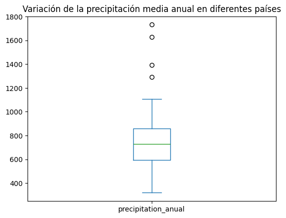

```python
import matplotlib.pyplot as plt

DF['precipitation_anual'].plot(kind='box')
plt.title('Variación de la precipitación media anual en diferentes países')
plt.show()
```

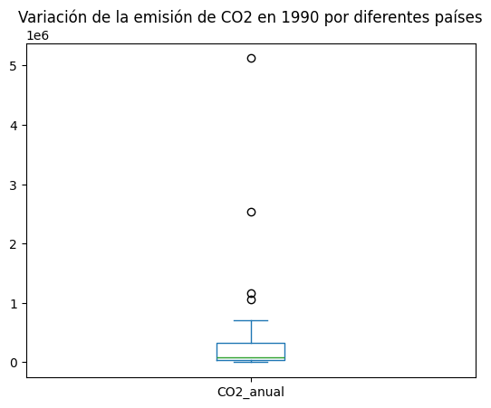

```python
DF[['CO2_anual']].plot(kind='box')
plt.title('Variación de la emisión de CO2 en 1990 por diferentes países')
plt.show()
```

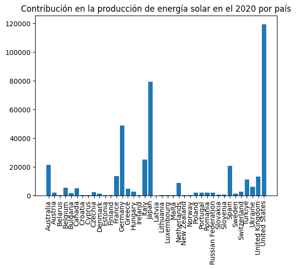

```python
plt.bar(DF['Country'], DF['solar_energy_anual'])
plt.xticks(rotation=90)
plt.title('Contribución en la producción de energía solar en el 2020 por país')
plt.show()
```

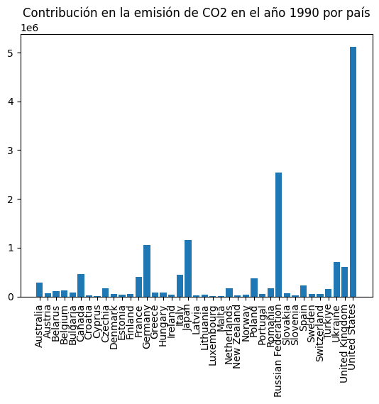

```python
plt.bar(DF['Country'], DF['CO2_anual'])
plt.xticks(rotation=90)
plt.title('Contribución en la emisión de CO2 en el año 1990 por país')
plt.show()
```